# Tarea Descomposición

Author

Ana Sofía Hinojosa Bale

# Tarea

## Ejercicio 1

Tomando el PIB de cada país, GDP, contenido en la tabla global_economy, grafique el PIB per cápita a lo largo del tiempo.

```r
library(tidyverse)
library(fpp3)
```

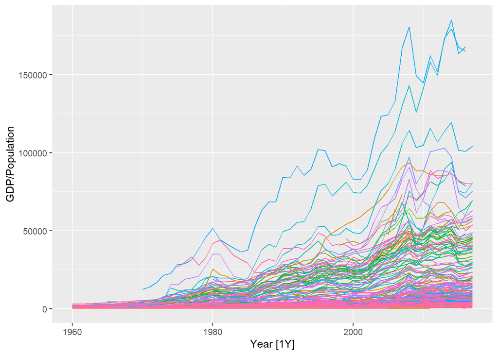

```r
pib_tsbl <- global_economy |>
  autoplot(GDP/Population) +
  theme(legend.position = "none")

pib_tsbl
```

### Cómo ha sido la evolución de la economía de los países en el tiempo?

Ha incrementado en la mayoría de los países, ya que las series tienen una tendencia alcista, lo que significa que el PIB per cápita ha ido creciendo a lo largo del tiempo.

### ¿Cuál país tiene el mayor PIB per cápita?

```r
global_economy |>
  mutate(gdp_per_capita = GDP/Population) |>
  select(-c(Code, Growth:Exports)) |>
  filter(Year %in% 2010:2017) |>
  as_tibble() |>
  group_by(Country) |>
  summarise(mean_gdppc = mean(gdp_per_capita, na.rm = TRUE)) |>
  arrange(desc(mean_gdppc))
```

| Country | mean_gdppc |
| --- | --- |
| Monaco | 163978.0610 |
| Liechtenstein | 162023.4048 |
| Luxembourg | 108326.8560 |
| Norway | 88912.6961 |
| Bermuda | 86346.7517 |
| Switzerland | 82543.6696 |
| Isle of Man | 80995.6038 |
| Macao SAR, China | 76201.0046 |
| Qatar | 75930.9512 |
| Australia | 59098.6552 |

[output cut: 253 more lines]

El país que tiene mayor PIB per cápita es Mónaco.

## Ejercicio 2

Grafique las siguientes series de tiempo y transfórmelas y/o ajústelas si lo considera necesario. ¿Qué efecto tuvo la transformación?

### i - PIB de EEUU

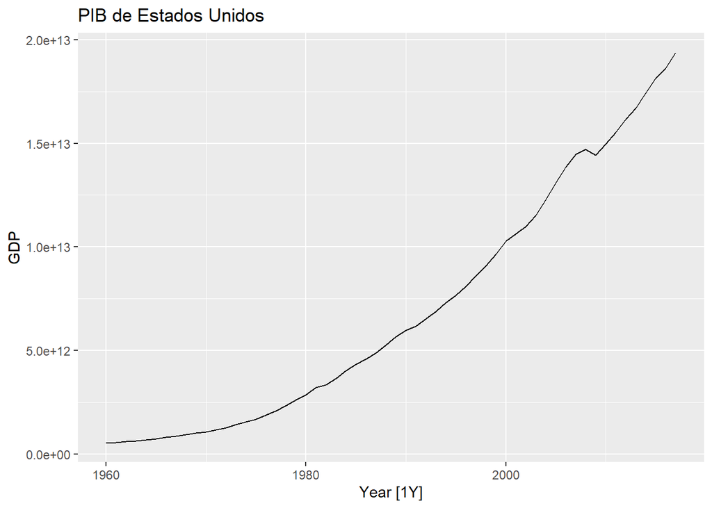

```r
pibusa_tsbl <- global_economy |>
  filter(Country == "United States") |>
  autoplot(GDP) + ggtitle("PIB de Estados Unidos")
pibusa_tsbl
```

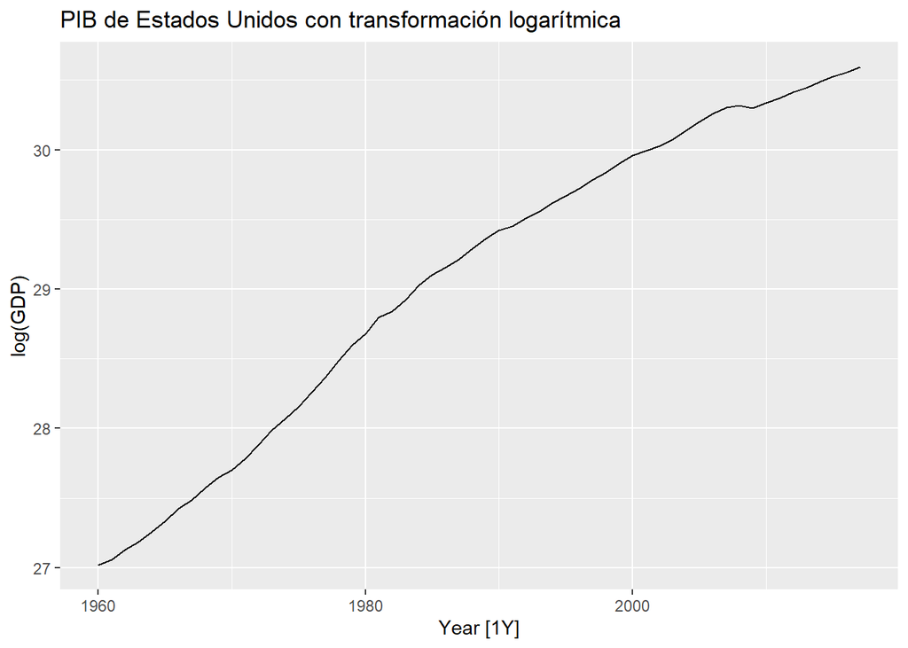

```r
pibusa_log <- global_economy |>
  filter(Country == 'United States') |>
  autoplot(log(GDP)) + ggtitle("PIB de Estados Unidos con transformación logarítmica")
pibusa_log
```

### ii - PIB de México

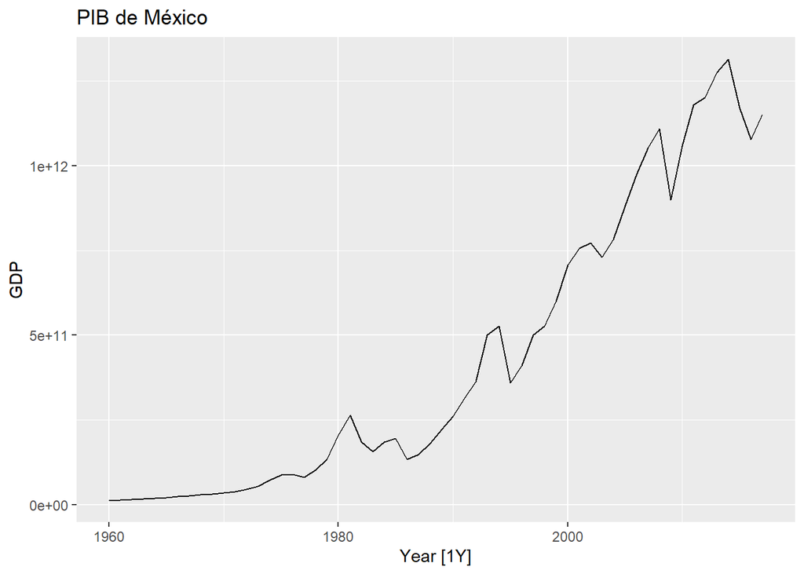

```r
pibmex_tsbl <- global_economy |>
  filter(Country == "Mexico") |>
  autoplot(GDP) + ggtitle("PIB de México")
pibmex_tsbl
```

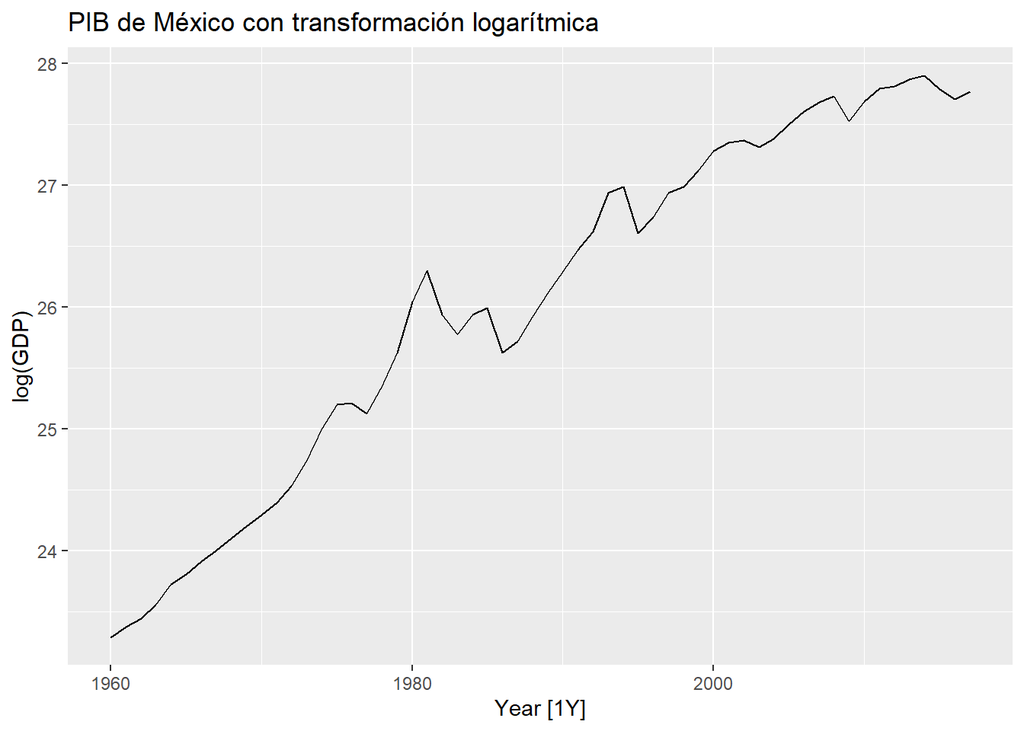

```r
pibmex_log <- global_economy |>
  filter(Country == "Mexico") |>
  autoplot(log(GDP)) + ggtitle("PIB de México con transformación logarítmica")
pibmex_log
```

### iii - Demanda de electricidad en el estado de Victoria (Australia)

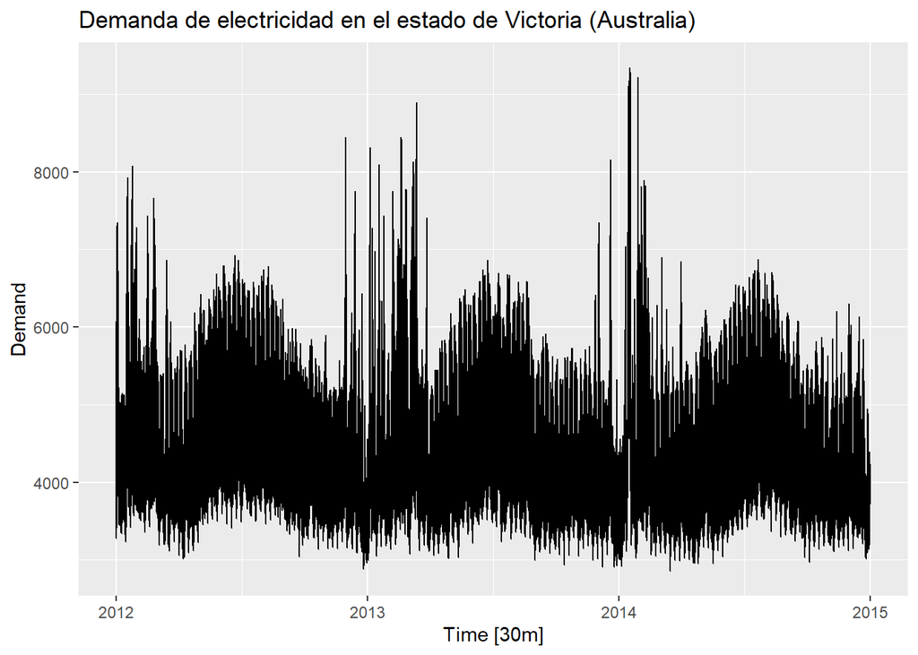

```r
vic_elec |>
  autoplot(Demand) + ggtitle("Demanda de electricidad en el estado de Victoria (Australia)")
```

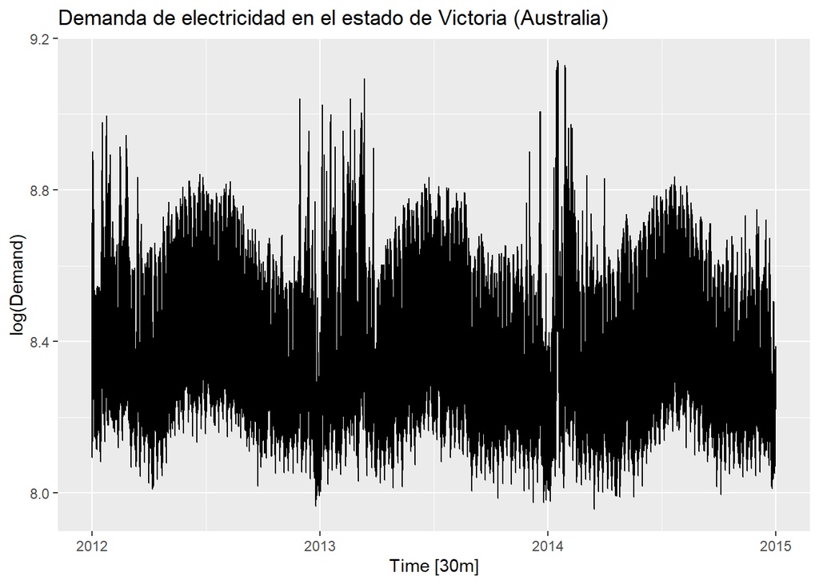

```r
vic_log <- vic_elec |>
  autoplot(log(Demand)) + ggtitle("Demanda de electricidad en el estado de Victoria (Australia)")
vic_log
```

### ¿Qué efectos tuvieron las transformaciones?

En el caso de la serie de tiempo del PIB de México, se puedde ver que en la serie original, su varianza va aumentando con el tiempo, aunque poco, por lo que transformación logarítmica permite estabilizar esta varianza.

En el caso de la serie de tiempo del PIB de Estados Unidos, mientras que en la originall se muestra una tendencia exponencial, se puede observar que la transformación logarítmica la hizo un poco más lineal.

## Ejercicio 3

```
Plot variable not specified, automatically selected `.vars = Volume`
```

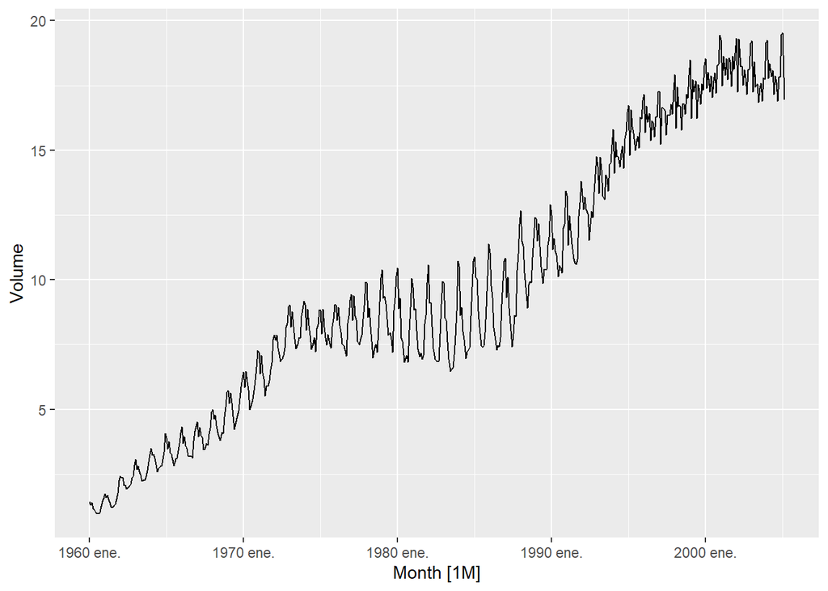

```r
canadian_gas |>
  autoplot()
```

### ¿Es útil realizar una transformación de Box-Cox a los datos canadian_gas? ¿Por qué sí o por qué no?

```r
# Transformación Box-Cox

(lambda <- canadian_gas %>%
  features(Volume, features = guerrero) %>%
  pull(lambda_guerrero))
```

```
[1] 0.5767648
```

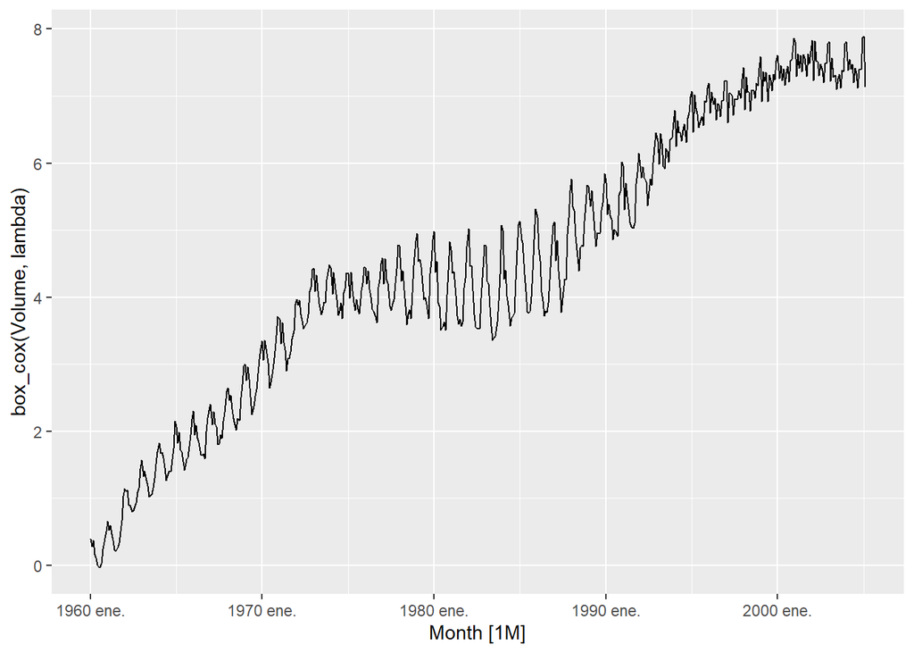

```r
canadian_gas %>% autoplot(box_cox(Volume, lambda))
```

La transformación no resulta útil, ya que no presenta ventajas, no se estabiliza la varianza ni se normaliza la distribución, y aunque puede que sí facilite la interpretación de la serie, no genera una gran diferencia.

## Ejercicio 4

El dataset fma::plastics tiene información de las ventas mensuales (medidas en miles) del producto A para un productor de plásticos, a lo largo de cinco años.

### i

#### Grafique la serie de tiempo para el producto A.

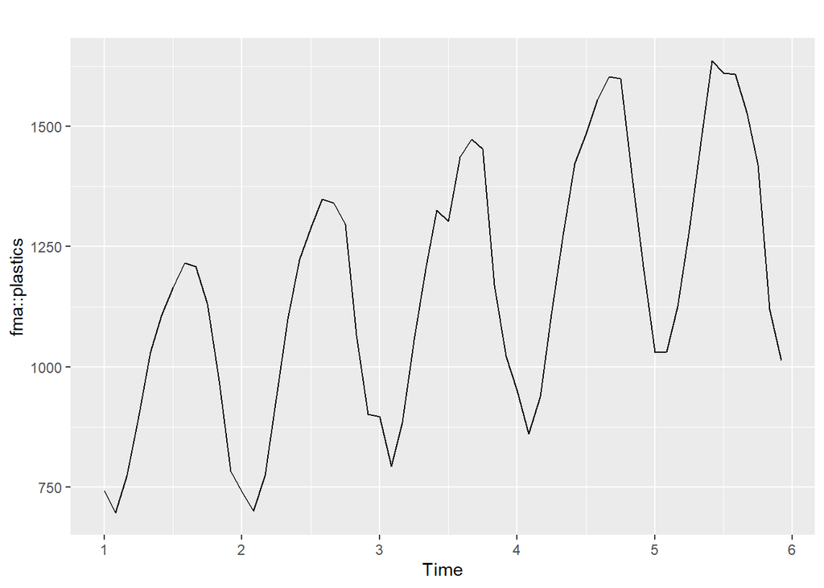

```r
fma::plastics |>
  autoplot()
```

#### ¿Identifica algún componente de tendencia-ciclo y/o estacional?

Sí, la tendencia es alcista, ya que con el tiempoo va aumentando, además de que la serie presenta estacionalidad anual.

### ii

#### Utilice una descomposición clásica multiplicativa para calcular el componente de tendencia y estacional

```r
plastics_tsbl <- as_tsibble(fma::plastics)
```

```r
plastics_decomp <- plastics_tsbl |>
  model(
    clasica = classical_decomposition(value,
                                      type = "multiplicative")
  )
```

```r
plastics_components <- plastics_decomp |>
  components()

plastics_components
```

| .model | index | value | trend | seasonal | random | season_adjust |
| --- | --- | --- | --- | --- | --- | --- |
| clasica | 0001 ene. | 742 | NA | 0.7670466 | NA | 967.3468 |
| clasica | 0001 feb. | 697 | NA | 0.7103357 | NA | 981.2262 |
| clasica | 0001 mar. | 776 | NA | 0.7765294 | NA | 999.3182 |
| clasica | 0001 abr. | 898 | NA | 0.9103112 | NA | 986.4758 |
| clasica | 0001 may. | 1030 | NA | 1.0447386 | NA | 985.8925 |
| clasica | 0001 jun. | 1107 | NA | 1.1570026 | NA | 956.7826 |
| clasica | 0001 jul. | 1165 | 976.9583 | 1.1636317 | 1.0247887 | 1001.1759 |
| clasica | 0001 ago. | 1216 | 977.0417 | 1.2252952 | 1.0157335 | 992.4139 |
| clasica | 0001 sep. | 1208 | 977.0833 | 1.2313635 | 1.0040354 | 981.0263 |
| clasica | 0001 oct. | 1131 | 978.4167 | 1.1887444 | 0.9724119 | 951.4241 |

[output cut: 50 more lines]

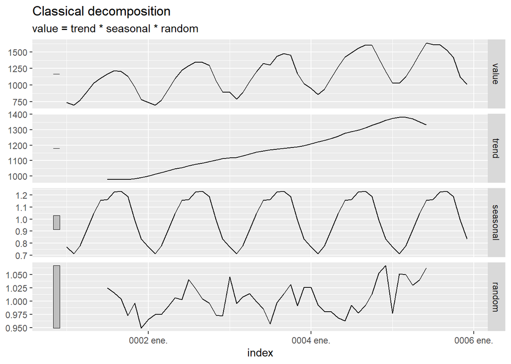

```r
plastics_components |>
  autoplot()
```

### iii

#### ¿Los resultados coinciden con su respuesta al inciso i?

Sí, como se puede ver, la tendencia sí es a la alta y sí presenta estacionalidad anual.

### iv

#### Calcule y grafique los datos desestacionalizados

```
Plot variable not specified, automatically selected `.vars = season_adjust`
```

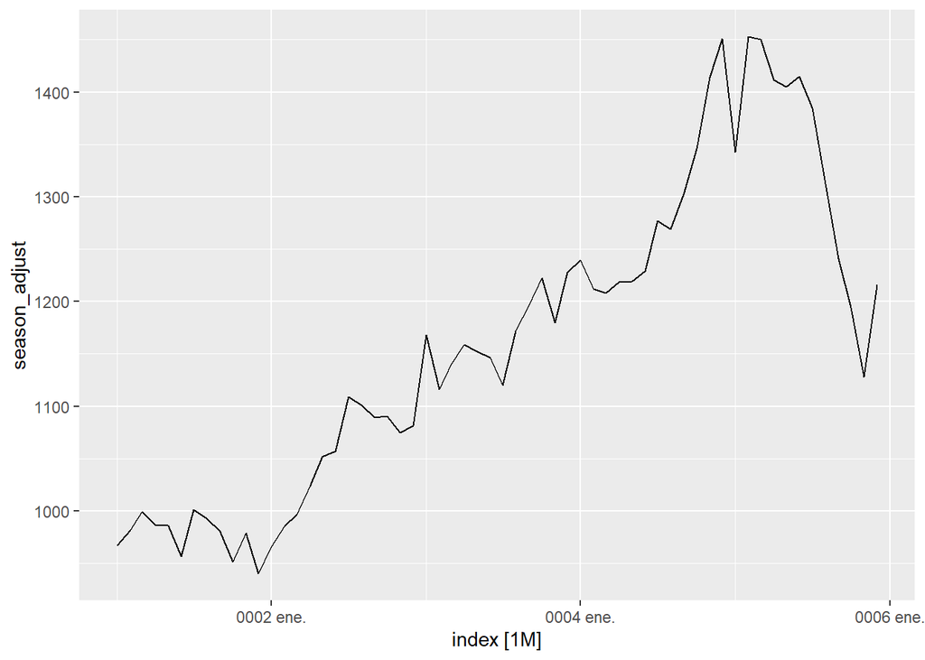

```r
datos_desestacionalizados <- plastics_components |>
  select(index, season_adjust)
autoplot(datos_desestacionalizados)
```

### v

#### Cambie, manualmente, una observación para que sea un outlier (p. ej., sume 500 a una observación). Vuelva a estimar los datos desestacionalizados. ¿Cuál fue el efecto de ese outlier?

```r
outlier_tsbl <- plastics_tsbl |>
  mutate(value = value + 500  * (value == 1528))

outlier_tsbl
```

| index | value |
| --- | --- |
| 0001 ene. | 742 |
| 0001 feb. | 697 |
| 0001 mar. | 776 |
| 0001 abr. | 898 |
| 0001 may. | 1030 |
| 0001 jun. | 1107 |
| 0001 jul. | 1165 |
| 0001 ago. | 1216 |
| 0001 sep. | 1208 |
| 0001 oct. | 1131 |

[output cut: 50 more lines]

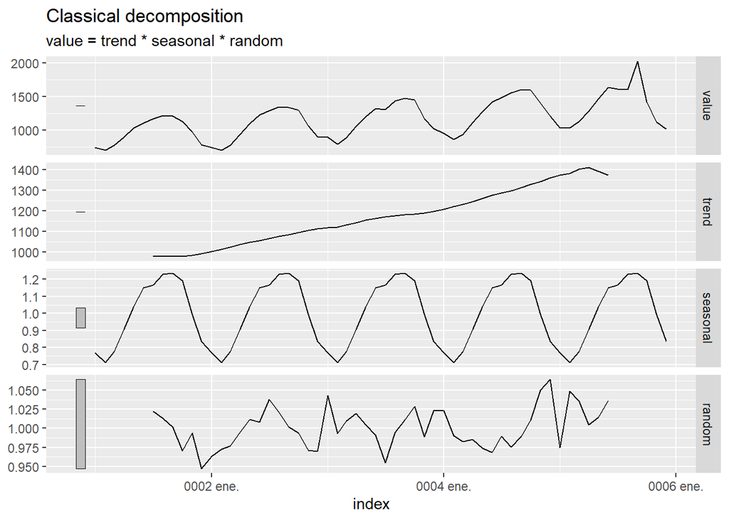

```r
outlier_decomp <- outlier_tsbl |>
  model(
    clasica = classical_decomposition(value,
                                      type = "multiplicative"))

outlier_components <- outlier_decomp |>
  components()

outlier_components |>
  autoplot()
```

```
Plot variable not specified, automatically selected `.vars = season_adjust`
```

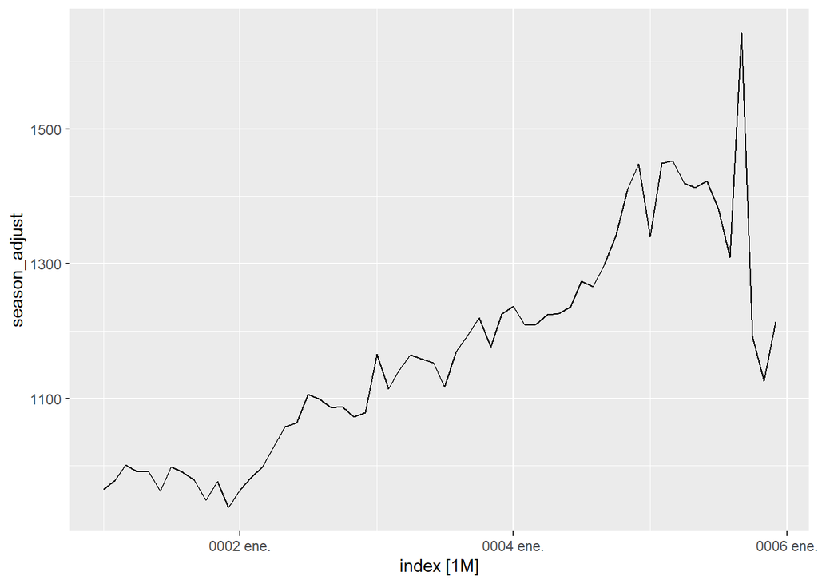

```r
outlier_desestacionalizados <- outlier_components |>
  select(index, season_adjust)
autoplot(outlier_desestacionalizados)
```

El efecto de este outlier es que tanto la tendencia como la estacionalidad presentan modificaciones, y en los datos desestacionalizados se puede observar que un cambio co,mo este genera complicaciones en la visualización del gráfico.

### vi

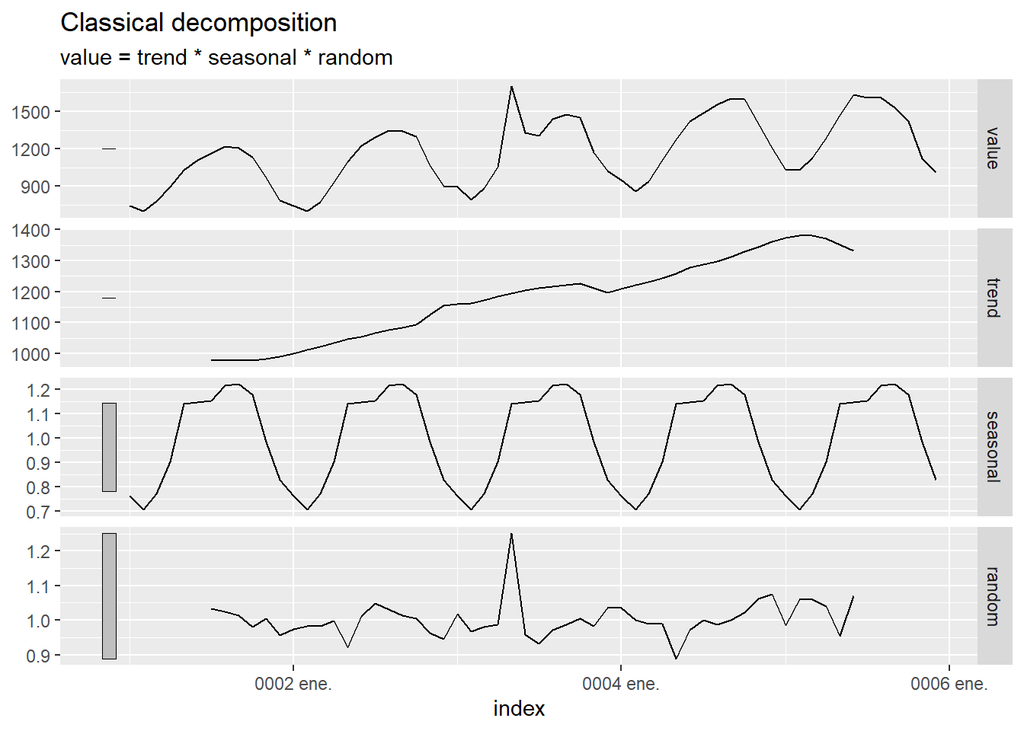

```r
outliermedio_tsbl <- plastics_tsbl |>
  mutate(value = value + 500  * (value == 1204))

outliermedio_decomp <- outliermedio_tsbl |>
  model(
    clasica = classical_decomposition(value,
                                      type = "multiplicative"))

outliermedio_components <- outliermedio_decomp |>
  components()

outliermedio_components |>
  autoplot()
```

```
Plot variable not specified, automatically selected `.vars = season_adjust`
```

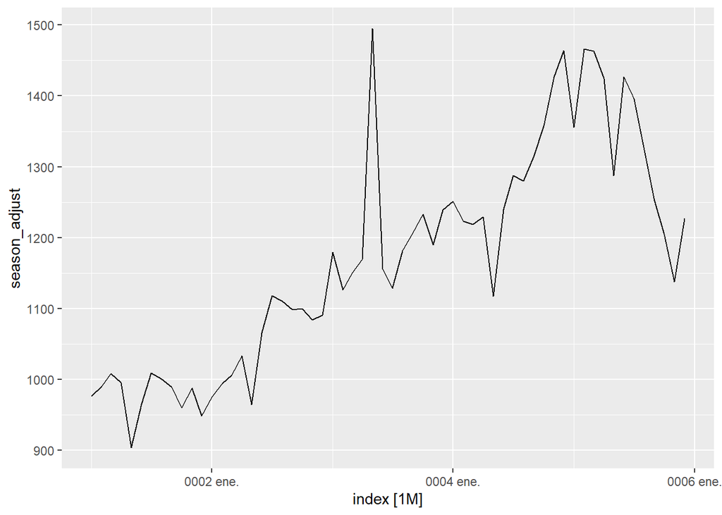

```r
outliermedio_desestacionalizados <- outliermedio_components |>
  select(index, season_adjust)
autoplot(outliermedio_desestacionalizados)
```

#### ¿Hace alguna diferencia que el outlier se encuentre cerca del final de la serie o más alrededor del centro?

```
Plot variable not specified, automatically selected `.vars = season_adjust`
```

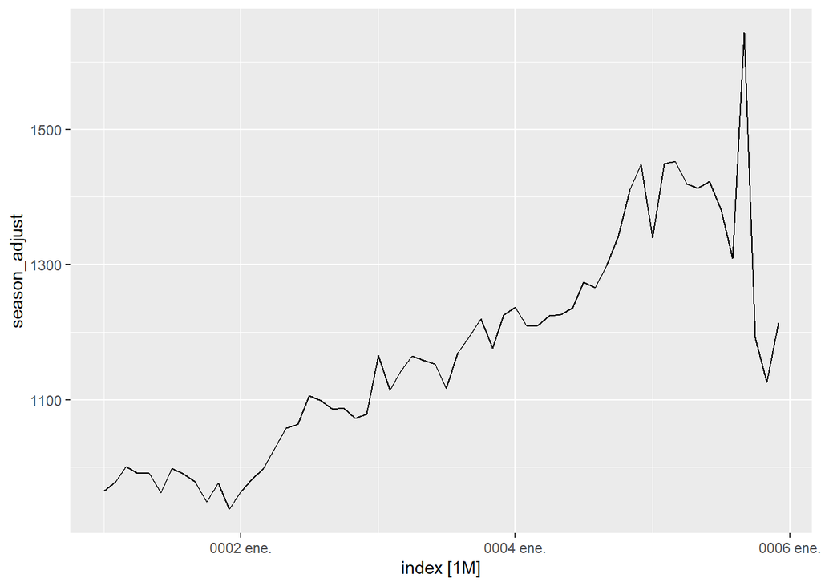

```r
autoplot(outlier_desestacionalizados)
```

```
Plot variable not specified, automatically selected `.vars = season_adjust`
```

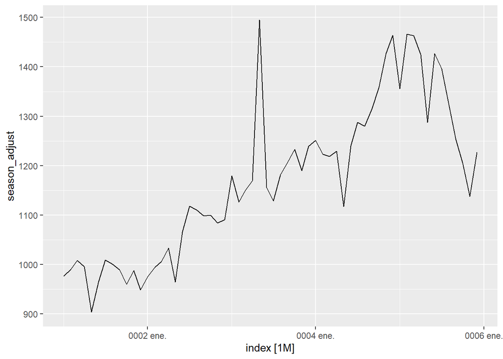

```r
autoplot(outliermedio_desestacionalizados)
```

Sí hay una diferencia, ya que no solo se modifican los valores de outlier, sino que también se han modificado otros valores al hacer la descomposición.